# Cleaning and standardizing spectra

Jose Eduardo Meireles

July 2026

Raw leaf spectra are rarely analysis-ready. They carry sensor noise, they arrive on whatever band grid the instrument used, and they differ in overall brightness because of illumination geometry, leaf angle, and specular glare that have nothing to do with the biochemistry you care about. This vignette walks through `spectrolab`’s tools for fixing those three problems – **smoothing**, **resampling**, and **normalizing** (plus **derivatives** along the way) – and closes with the order in which to apply them.

Every transform here takes a `spectra` object and returns one, and every one **requires strictly increasing bands**. If your data still carries overlapping sensor ranges, splice them with `match_sensors()` first (see the Matching sensor overlap vignette).

We use the simulated `spec_matrix_example` dataset throughout – 50 spectra, 400-2500 nm, with 10 species encoded in the sample names. Because it is simulated, it is convenient for illustration but is not a substitute for real measurements.

```r
s = as_spectra(spec_matrix_example, name_idx = 1)   # simulated: 50 samples, 10 species
s
```

```
#> spectra object
#> number of samples: 50
#> bands: 400 to 2500 (2101 bands)
#> metadata: none
#>
#>            400                401                402
#> species_7  0.0409999850000255 0.0410392346804256 0.04106549994583
#> species_8  0.0409962044286894 0.0410353382475394 0.0410614986994235
#> species_5  0.0410009904793496 0.0410404205990898 0.0410668814132104
#> species_7  0.0409983698664643 0.0410375234860887 0.0410636927693175
#> species_10 0.0409991416221446 0.0410383501198347 0.0410645753123711
#>            403                404                405
#> species_7  0.0411176913920641 0.0412088689409777 0.0413002645716231
#> species_8  0.0411135913885245 0.0412046591541176 0.0412958756998439
#> species_5  0.0411192648210274 0.0412106251159301 0.0413022209479067
#> species_7  0.0411157918560658 0.0412068761381853 0.0412981496209886
#> species_10 0.0411167280801826 0.0412078653476602 0.0412992056048533
#>            406                ...
#> species_7  0.0414047926564346
#> species_8  0.0414001880928309
#> species_5  0.0414069455006203
#> species_7  0.041402543837837
#> species_10 0.0414036712997242
```

```r
one = s[1, ]   # a single spectrum, for the before/after smoothing panels
```

## Smoothing

Smoothing suppresses band-to-band noise while preserving the shape of the spectrum. `smooth()` dispatches to four methods via its `method` argument:

| `method` | function | idea |
| --- | --- | --- |
| `"gaussian"` (default) | `smooth_fwhm()` | resample onto the same bands using a wider Gaussian FWHM (see Resampling below) |
| `"spline"` | `smooth_spline()` | fit `stats::smooth.spline()` per sample |
| `"moving_average"` | `smooth_moving_avg()` | simple moving average over `n` adjacent bands |
| `"sgolay"` | `smooth_sgolay()` | Savitzky-Golay filter: a local polynomial fit over a moving window (requires the `signal` package) |

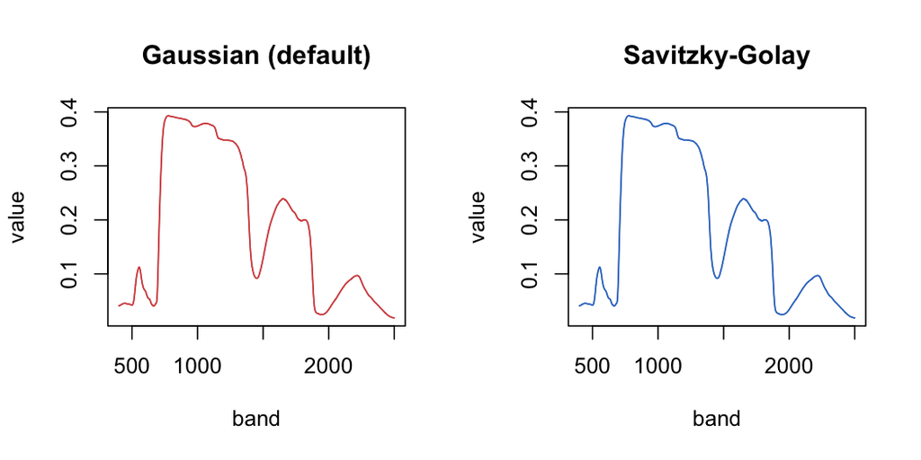

```r
s_gauss = smooth(one, method = "gaussian")
s_sg    = suppressMessages(smooth(one, method = "sgolay"))

oldpar = par(no.readonly = TRUE)
par(mfrow = c(1, 2))

plot(one, lwd = 1, col = spec_muted, main = "Gaussian (default)")
plot(s_gauss, add = TRUE, col = spec_pal[6], lwd = 1)

plot(one, lwd = 1, col = spec_muted, main = "Savitzky-Golay")
plot(s_sg, add = TRUE, col = spec_pal[1], lwd = 1)
```

```r
par(oldpar)
```

### The Savitzky-Golay filter in more detail

`smooth_sgolay(x, p, n)` fits a degree-`p` polynomial over a moving window of `n` bands and replaces the center value with the fitted one. `n` must be odd and greater than `p`; the default, `n = p + 3 - p %% 2`, is deliberately small (5 bands, for the default `p = 3`) so it does very little smoothing until you widen the window:

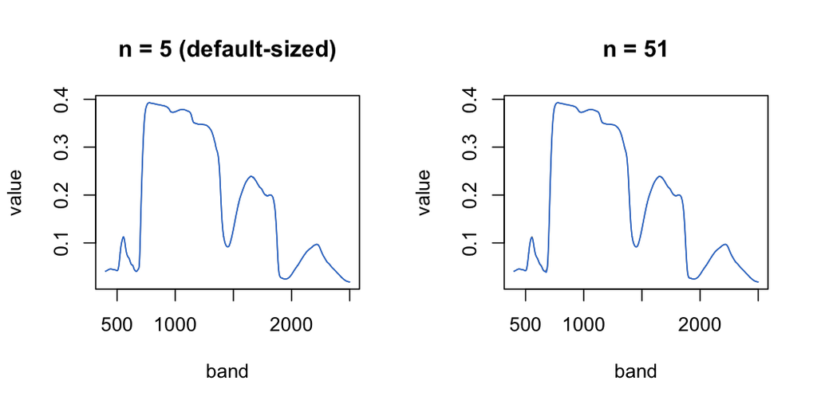

```r
s_narrow = smooth_sgolay(one, p = 3, n = 5)    # default-sized window
s_wide   = smooth_sgolay(one, p = 3, n = 51)   # a much wider window

oldpar = par(no.readonly = TRUE)
par(mfrow = c(1, 2))

plot(one, lwd = 1, col = spec_muted, main = "n = 5 (default-sized)")
plot(s_narrow, add = TRUE, col = spec_pal[1], lwd = 1)

plot(one, lwd = 1, col = spec_muted, main = "n = 51")
plot(s_wide, add = TRUE, col = spec_pal[1], lwd = 1)
```

```r
par(oldpar)
```

Unlike a simple moving average, the Savitzky-Golay filter has full-length output at the edges (no bands are dropped there) because its polynomial fit is defined at every point in the window, including the boundary – see the Gotchas below for how `smooth_moving_avg()` differs.

### Smoothing gotchas

- **The `signal` package is required for `smooth_sgolay()` and `deriv_spectra()`**, but it is only in `Suggests` – if it is not installed you get a clear error telling you to install it, rather than a cryptic one.
- **The method name is `"sgolay"`**, not `"savitzky_golay"` or `"savgol"` – matching the naming of the underlying `signal::sgolay()`/`sgolayfilt()` functions it wraps.
- **`smooth_moving_avg()` can silently drop bands.** Its moving average produces `NA` at the edges (there are not enough neighbors to average there), and those edge bands are then *removed* from the result – your output can have fewer bands than the input. The dropped values are stashed into metadata (`save_bands_to_meta = TRUE`, the default) so they are not lost, just relocated. `smooth_sgolay()` does not have this issue.
- **Choose the Savitzky-Golay window (`n`) relative to your spectral resolution**, not in the abstract: 5 bands means something very different on 1 nm-resolution data than on 10 nm data. The default is intentionally small; widen it deliberately, and check the result visually as we did above.

## Derivatives and the red edge

`deriv_spectra(x, order)` computes the order-`order` derivative of each spectrum using the same Savitzky-Golay machinery (also requires `signal`). Derivatives emphasize subtle inflection points that are hard to see in raw reflectance.

The classic example is the **red edge**: the steep rise in reflectance between the chlorophyll absorption in the red (~680 nm) and the bright NIR plateau (~750 nm). Its inflection point – the wavelength of steepest slope – shows up as a sharp peak in the **first derivative**, and its position shifts with chlorophyll content and physiological stress. That is exactly what a derivative exposes:

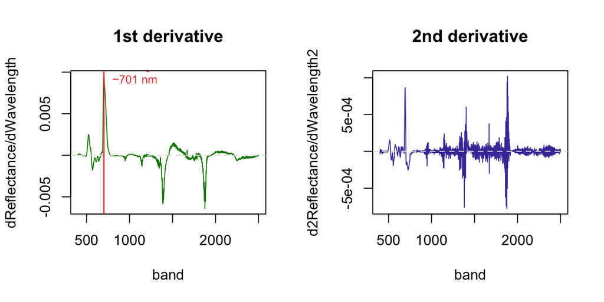

```r
d1 = suppressMessages(deriv_spectra(one, order = 1))
d2 = suppressMessages(deriv_spectra(one, order = 2))

# The red-edge position: wavelength of the largest 1st-derivative value in the
# red/NIR transition (roughly 680-760 nm).
red_edge_win = bands(d1) >= 680 & bands(d1) <= 760
rep_nm       = bands(d1)[red_edge_win][which.max(value(d1)[1, red_edge_win])]

oldpar = par(no.readonly = TRUE)
par(mfrow = c(1, 2))

plot(d1, main = "1st derivative", col = spec_pal[4],
     ylab = "dReflectance/dWavelength")
abline(h = 0, col = spec_grid, lty = 2)
abline(v = rep_nm, col = spec_pal[6], lwd = 1.5)
text(rep_nm, max(value(d1)[1, ]), labels = paste0("red edge\n~", rep_nm, " nm"),
     pos = 4, col = spec_pal[6], cex = 0.8)

plot(d2, main = "2nd derivative", col = spec_pal[5],
     ylab = "d2Reflectance/dWavelength2")
abline(h = 0, col = spec_grid, lty = 2)
```

```r
par(oldpar)
```

`deriv_spectra()` (like `smooth_sgolay()` with a derivative order > 0) emits a message reminding you that the output is **no longer reflectance/radiance** – the y-axis units have changed. Pass `quiet = TRUE` once you know that. The values still flow into any downstream function (`normalize()`, the two-band spectral indices), so nothing stops you from processing them further; it is on you to remember what the axis now means.

## Resampling to a common grid

Different instruments – or the same instrument at different settings – report spectra on different band grids: different starting wavelength, spacing, or count. Before you can compare or combine them, you must bring them onto a common grid. `resample()` does this, but it is **not** naive linear interpolation: it models each new band as a **Gaussian-weighted average of nearby original bands**, using the **Full Width at Half Maximum (FWHM)** of the new band as the Gaussian’s spread. This mimics how a real detector integrates light over a small window, rather than pretending the instrument measured an infinitely narrow slice at each wavelength.

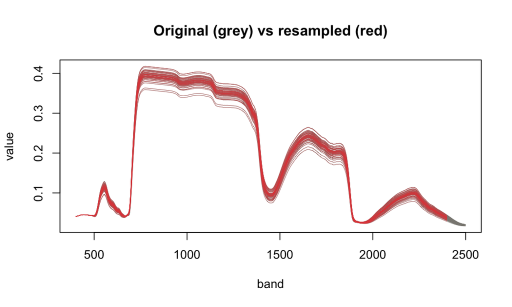

```r
new_bands = seq(400, 2400, 5)
fwhm      = make_fwhm(s, new_bands)

s_resamp  = resample(s, new_bands = new_bands, fwhm = fwhm)

plot(s, lwd = 0.5, col = spec_muted, main = "Original (grey) vs resampled (red)")
plot(s_resamp, add = TRUE, lwd = 0.25, col = spec_pal[6])
```

### Where the FWHM comes from

`resample()` needs one FWHM value per new band. `make_fwhm()` estimates a sensible one from the spacing of the *original* bands, resampled (via the same Gaussian model) onto the *new* grid, so a new band is never narrower than the data that feeds it.

```r
length(fwhm) == length(new_bands)   # one value per new band
```

```
#> [1] TRUE
```

```r
range(fwhm)
```

```
#> [1] 5 5
```

You can also supply your own FWHM (e.g. straight from the instrument’s specs) – a single number recycled across all new bands, or one value per new band.

### Resampling gotchas

**Requested bands outside the original range come back as `NA`.** `resample()` will not invent data beyond the edges of what you measured. Each new band is a Gaussian response, and `resample()` checks how much of that response is actually covered by original bands. Any `new_bands` whose coverage falls below `coverage_min` (default `0.5`) – those past the edges of the measured range, or inside a gap – are returned as `NA` with a warning. The requested grid is always kept intact, so the result lines up with the grid you asked for:

```r
too_wide = seq(330, 2525, 5)
s_wide   = suppressWarnings(resample(s, new_bands = too_wide, fwhm = 5))

range(bands(s))                  # what we actually measured
```

```
#> [1]  400 2500
```

```r
range(bands(s_wide))             # the full requested grid is preserved ...
```

```
#> [1]  330 2525
```

```r
sum(is.na(value(s_wide)[1, ]))   # ... but the out-of-range bands are NA
```

```
#> [1] 19
```

`NA` propagates honestly through downstream workflows instead of pretending the sensor measured something it did not – drop the `NA` bands yourself if you want a compact object.

**Upsampling does not add real spectral detail.** Asking for a finer spacing than your instrument records (e.g. 1 nm data to 0.1 nm) runs without error and produces smoothly interpolated values, but it cannot recover detail the sensor never captured. Treat upsampled data as a smoother *display* of the original measurement, not as new information.

## Normalizing

Two leaves of the same species, measured moments apart, can differ by tens of percent in overall brightness purely because of illumination geometry and specular glare – variation that swamps the biochemical signal you want. **Vector normalization** removes it by dividing each spectrum by its own magnitude (`sqrt(sum(value^2))`), so every spectrum has unit length and only its *shape* remains.

```r
s_norm = normalize(s)
```

```
#> Vector normalizing spectra...
#> Note that y values will not be true values anymore!
```

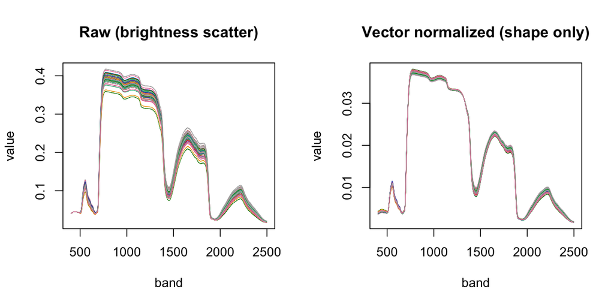

```r
cols = species_cols(s)

oldpar = par(no.readonly = TRUE)
par(mfrow = c(1, 2))

plot(s, lwd = 0.6, col = cols, main = "Raw (brightness scatter)")

plot(s_norm, lwd = 0.6, col = cols, main = "Vector normalized (shape only)")
```

```r
par(oldpar)
```

The same tightening is visible as shrinking quantile envelopes. Here are the 95% per-band ribbons for one species before and after – the normalized ribbon is markedly narrower:

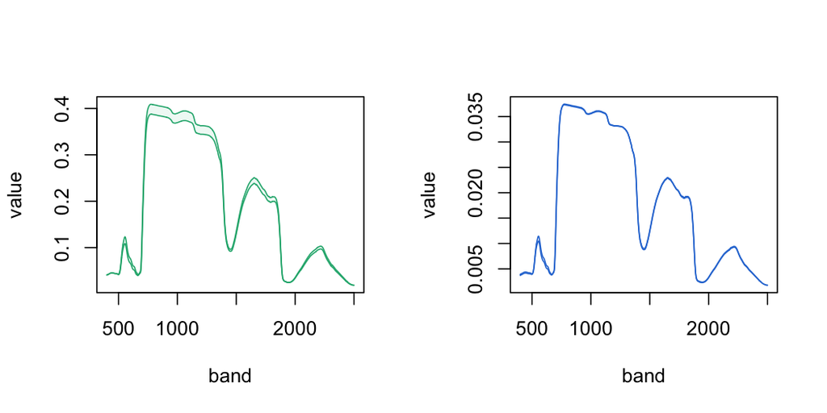

```r
sp        = names(s)[1]
one_sp    = s[names(s) == sp, ]
one_sp_n  = s_norm[names(s_norm) == sp, ]

oldpar = par(no.readonly = TRUE)
par(mfrow = c(1, 2))

plot_quantile(one_sp, total_prob = 0.95, col = spec_region_tints[2],
              border = spec_pal[2], main = paste(sp, "- raw"))
plot_quantile(one_sp_n, total_prob = 0.95, col = spec_region_tints[1],
              border = spec_pal[1], main = paste(sp, "- normalized"))
```

```r
par(oldpar)
```

`normalize()` messages that the y values are no longer true reflectance (pass `quiet = TRUE` to silence it) and stashes each spectrum’s original magnitude in metadata as `normalization_magnitude`, so the brightness you divided out is recorded rather than lost.

## Recommended order

These steps compose, and the order matters. A sensible default pipeline is:

1. **`match_sensors()`** – splice overlapping detector ranges so bands become strictly increasing. Everything downstream requires this.
2. **`smooth()`** – suppress band-to-band noise on the native grid.
3. **`deriv_spectra()`** *(optional)* – if your analysis works on derivatives (e.g. red-edge position), compute them here, remembering the y-axis is no longer reflectance.
4. **`resample()`** – bring every spectrum onto the common band grid you will analyze on.
5. **`normalize()`** *(optional)* – remove overall brightness so comparisons reflect spectral shape.

Every one of steps 2-5 requires **strictly increasing bands**, which is why `match_sensors()` comes first. When in doubt, plot after each step: these transforms are cheap, and a quick before/after view catches most mistakes before they reach your analysis.